# Solution

#### Project URL

##### https://github.com/GreatLearningAIML1/gl-pgp-aiml-uta-intl-may20-PoonamPathaknpc/tree/master/Esemble_Techniques_Project

#### 1. Univariate analysis

#### a. Univariate analysis – data types and description of the independent attributes which should include (name, meaning, range of values observed, central values (mean and median), standard deviation and quartiles, analysis of the body of distributions / tails, missing values, outliers.

```python
#import libraries
import numpy as np # linear algebra
import pandas as pd # data processing, CSV file I/O (e.g. pd.read_csv)
import matplotlib.pyplot as plt       # matplotlib.pyplot plots data
from sklearn.externals.six import StringIO
from IPython.display import display, HTML
%matplotlib inline
import seaborn as sns
```

```python
csv = pd.read_csv("bank-full.csv")
csv.head(10)
```

|  | age | job | marital | education | default | balance | housing | loan | contact | day | month | duration | campaign | pdays | previous | poutcome | Target |
| --- | --- | --- | --- | --- | --- | --- | --- | --- | --- | --- | --- | --- | --- | --- | --- | --- | --- |
| 0 | 58 | management | married | tertiary | no | 2143 | yes | no | unknown | 5 | may | 261 | 1 | -1 | 0 | unknown | no |
| 1 | 44 | technician | single | secondary | no | 29 | yes | no | unknown | 5 | may | 151 | 1 | -1 | 0 | unknown | no |
| 2 | 33 | entrepreneur | married | secondary | no | 2 | yes | yes | unknown | 5 | may | 76 | 1 | -1 | 0 | unknown | no |
| 3 | 47 | blue-collar | married | unknown | no | 1506 | yes | no | unknown | 5 | may | 92 | 1 | -1 | 0 | unknown | no |
| 4 | 33 | unknown | single | unknown | no | 1 | no | no | unknown | 5 | may | 198 | 1 | -1 | 0 | unknown | no |
| 5 | 35 | management | married | tertiary | no | 231 | yes | no | unknown | 5 | may | 139 | 1 | -1 | 0 | unknown | no |
| 6 | 28 | management | single | tertiary | no | 447 | yes | yes | unknown | 5 | may | 217 | 1 | -1 | 0 | unknown | no |
| 7 | 42 | entrepreneur | divorced | tertiary | yes | 2 | yes | no | unknown | 5 | may | 380 | 1 | -1 | 0 | unknown | no |
| 8 | 58 | retired | married | primary | no | 121 | yes | no | unknown | 5 | may | 50 | 1 | -1 | 0 | unknown | no |
| 9 | 43 | technician | single | secondary | no | 593 | yes | no | unknown | 5 | may | 55 | 1 | -1 | 0 | unknown | no |

```python
# shape
csv.shape
```

```
(45211, 17)
```

```python
#data types
csv.dtypes
```

```
age           int64
job          object
marital      object
education    object
default      object
balance       int64
housing      object
loan         object
contact      object
day           int64
month        object
duration      int64
campaign      int64
pdays         int64
previous      int64
poutcome     object
Target       object
dtype: object
```

##### Central values (mean and median), standard deviation and quartiles

```python
 pd.concat([csv.describe(),pd.DataFrame(csv.median() , columns = ["median"] ).T])
```

|  | age | balance | day | duration | campaign | pdays | previous |
| --- | --- | --- | --- | --- | --- | --- | --- |
| count | 45211.000000 | 45211.000000 | 45211.000000 | 45211.000000 | 45211.000000 | 45211.000000 | 45211.000000 |
| mean | 40.936210 | 1362.272058 | 15.806419 | 258.163080 | 2.763841 | 40.197828 | 0.580323 |
| std | 10.618762 | 3044.765829 | 8.322476 | 257.527812 | 3.098021 | 100.128746 | 2.303441 |
| min | 18.000000 | -8019.000000 | 1.000000 | 0.000000 | 1.000000 | -1.000000 | 0.000000 |
| 25% | 33.000000 | 72.000000 | 8.000000 | 103.000000 | 1.000000 | -1.000000 | 0.000000 |
| 50% | 39.000000 | 448.000000 | 16.000000 | 180.000000 | 2.000000 | -1.000000 | 0.000000 |
| 75% | 48.000000 | 1428.000000 | 21.000000 | 319.000000 | 3.000000 | -1.000000 | 0.000000 |
| max | 95.000000 | 102127.000000 | 31.000000 | 4918.000000 | 63.000000 | 871.000000 | 275.000000 |
| median | 39.000000 | 448.000000 | 16.000000 | 180.000000 | 2.000000 | -1.000000 | 0.000000 |

##### Histogram for all the numerical features

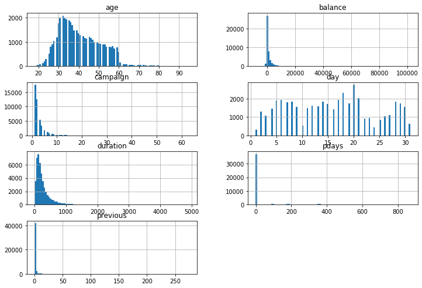

```python
columns = list(csv)[0:-1] # Excluding Outcome column which has only

csv[columns].hist(stacked=True, bins=100, figsize=(12,30), layout=(14,2));
```

##### Count plot of all the categorical columns

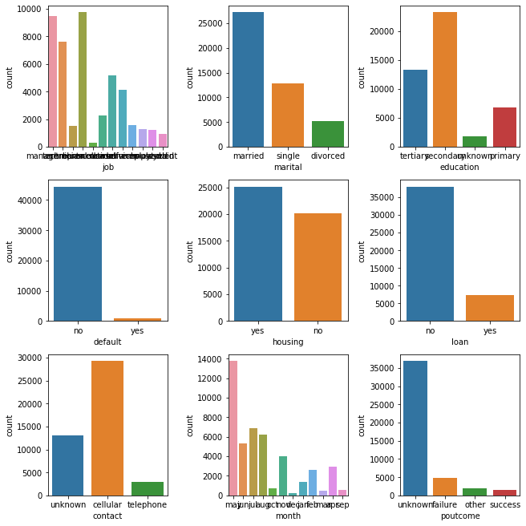

```python
lst = ['job','marital','education','default','housing','loan','contact','month','poutcome']

fig, axarr = plt.subplots(nrows=3, ncols=3,
                        figsize=(9, 9), constrained_layout=True)
for i, p in enumerate(lst):
  row = i//3;
  pos = i%3;
  sns.countplot(csv[p],ax=axarr[row][pos]);
#plt.show();
```

##### Missing information

```python
cData = pd.get_dummies(csv, columns=['poutcome'])
cData = pd.get_dummies(cData, columns=['contact'])
cData = pd.get_dummies(cData, columns=['education'])
cData


print('% of Clients whose poutcome is unknown = ',cData.query('poutcome_unknown == 1')['poutcome_unknown'].count()/cData['poutcome_unknown'].count()*100)
print('% of Clients with unknown communication type = ',cData.query('contact_unknown == 1')['contact_unknown'].count()/cData['contact_unknown'].count()*100)
print('% of Clients whose education infoemation is unknown = ',cData.query('education_unknown == 1')['education_unknown'].count()/cData['education_unknown'].count()*100)
```

```
% of Clients whose poutcome is unknown =  81.74780473778506
% of Clients with unknown communication type =  28.798301298356595
% of Clients whose education infoemation is unknown =  4.1074074893278185
```

```python
csv.isnull().any().any()
```

```
False
```

#### Observations on body of distributions / tails, missing values, outliers:

##### From the histogram plots and count plot of numerical and categorical values respectively following abservations can be made:

##### - There are no null values but attributes such as Education , poutcome and Communication have missing information in the form of unknowns.

##### - Feature 'poutcome' has around 81% of its values are unknown/missing information.

```python
csv['poutcome'].value_counts()
```

```
unknown    36959
failure     4901
other       1840
success     1511
Name: poutcome, dtype: int64
```

##### - From the below numerical attributes such as Duration, Previous and Balance have right skewed distribution with balance and previous as highly skewed.

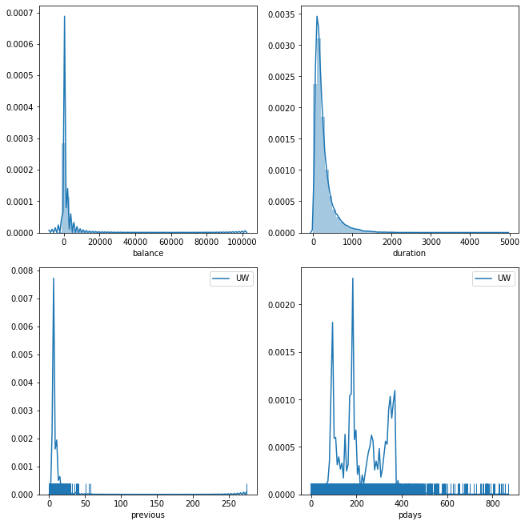

```python
lst = ['balance','duration','previous','pdays']

fig, axarr = plt.subplots(nrows=2, ncols=2,
                        figsize=(9, 9), constrained_layout=True)
for i, p in enumerate(lst):
  row = i//2;
  pos = i%2;
  if (p == 'previous' or p == 'pdays'):
    sns.distplot(csv[p],rug=True, hist=False, label='UW', kde_kws={'bw':0.1},ax=axarr[row][pos])
  else:
    sns.distplot(csv[p],ax=axarr[row][pos])
```

```python
for i, p in enumerate(lst):
    print(csv[p].skew())
```

```
8.360308326166326
3.144318099423456
41.84645447266292
2.6157154736563477
```

#### b. Strategies to address the different data challenges such as data pollution, outlier’s treatment and missing values treatment.

#### Handling missing values

##### - Since the data does not have any null values , we needn't fill such values or drop any fields.

##### - The data has missing information in the form of value called 'unknown' for columns such as Education , poutcome and Contact.

##### - Since poutcomes has 81% data as unknown , instead of handling the missing value , the column can be discarded in the as part of data preprocessing.

##### - For other columns , Education; unknown values can be dropped under one hot encoding

```python
csv['education'].value_counts()
```

```
secondary    23202
tertiary     13301
primary       6851
unknown       1857
Name: education, dtype: int64
```

```python
csv['contact'].value_counts()
```

```
cellular     29285
unknown      13020
telephone     2906
Name: contact, dtype: int64
```

##### Detecting and Handling Outliers:

```python
#Find inter quartile range in the data:
Q1 = csv.quantile(0.25)
Q3 = csv.quantile(0.75)
IQR = Q3 - Q1
print(IQR)
```

```
age           15.0
balance     1356.0
day           13.0
duration     216.0
campaign       2.0
pdays          0.0
previous       0.0
dtype: float64
```

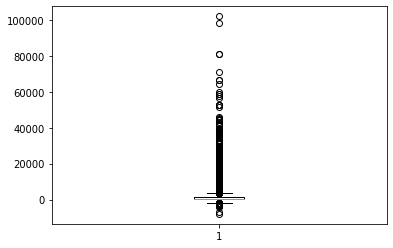

```python
#### Features balance and  previous  are heavily right skewed which means there are lot of outliers
# with extremly higher values


plt.boxplot(csv["balance"])
plt.show()
```

[output not shown]

[output not shown]

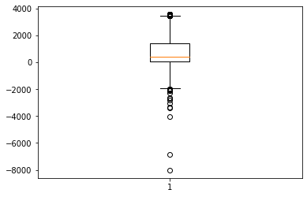

```python
print(csv['balance'].quantile(0.10))
print(csv['balance'].quantile(0.90))
csv["balanceNorm"] = np.where(csv["balance"] < 0.0, 0.0,csv["balance"])
csv["balanceNorm"] = np.where(csv["balance"] > 3574.0, 3574.0,csv["balance"])
# check the skew value again
print(csv["balanceNorm"].skew())
plt.boxplot(csv["balanceNorm"])
```

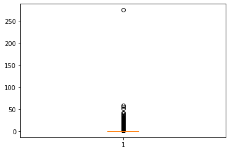

```python
plt.boxplot(csv["previous"])
plt.show()
```

[output not shown]

[output not shown]

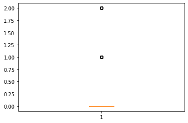

```python
print(csv['previous'].quantile(0.10))
print(csv['previous'].quantile(0.90))
csv["previousNorm"] = np.where(csv["previous"] < 0.0, 0.0,csv["previous"])
csv["previousNorm"] = np.where(csv["previous"] > 2.0, 2.0,csv["previous"])
# check the skew value again
print(csv["previousNorm"].skew())
plt.boxplot(csv["previousNorm"])
```

c. Please provide comments in jupyter notebook regarding the steps you take and insights drawn from the plots.

### 2. Multivariate Analysis

#### Corelation between the features to see the relationship in between the attributes:

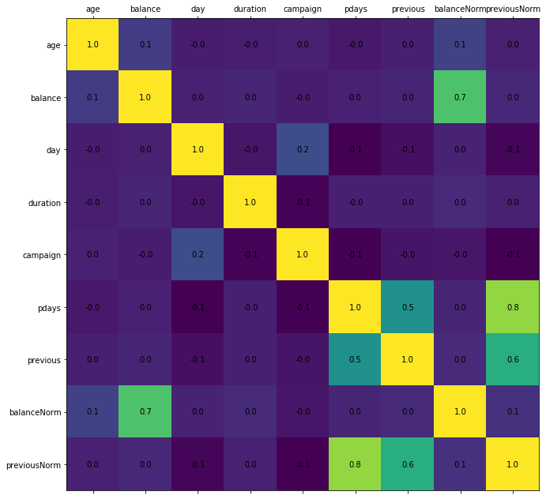

```python
# Correlation between features in graphical representation so below is function for that
def plot_corr(df, size=11):
    corr = df.corr()
    fig, ax = plt.subplots(figsize=(size, size))
    ax.matshow(corr)
    plt.xticks(range(len(corr.columns)), corr.columns)
    plt.yticks(range(len(corr.columns)), corr.columns)
    for (i, j), z in np.ndenumerate(corr):
        ax.text(j, i, '{:0.1f}'.format(z), ha='center', va='center')

plot_corr(csv)
```

##### Except pdays and previous attributes we do not see a strong corelation in between other attributes

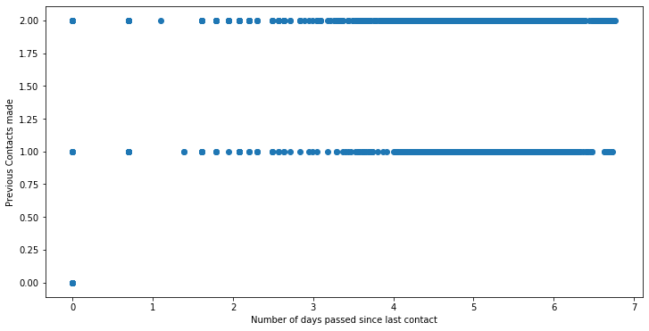

```python
csv["pdayslog"] = csv["pdays"].map(lambda i: np.log(i) if i > 0 else 0)
fig, ax = plt.subplots(figsize=(12,6))
ax.scatter(csv['pdayslog'],csv['previousNorm'])
ax.set_ylabel('Previous Contacts made')
ax.set_xlabel('Number of days passed since last contact')
plt.show()
```

##### Corelation between some numeric and categorical variable

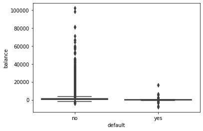

```python
sns.boxplot(csv['default'], csv['balance']);
```

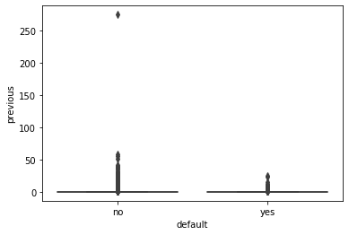

```python
sns.boxplot(csv['default'], csv['previous']);
```

##### - We see that client with higher account balance and the ones who were contacted more in the past have higher chances of not defaulting.

#### Relation between the predictor variables and target column

```python
from sklearn.preprocessing import LabelEncoder   # import label encoder
labelencoder = LabelEncoder()
csv["Target"] = labelencoder.fit_transform(csv.Target) # returns label encoded variable(s)
```

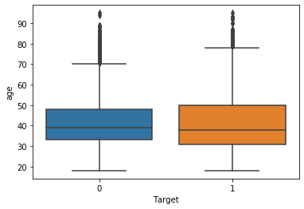

```python
sns.boxplot(csv['Target'],csv['age']);
```

##### - There does not seem to be a significant impact of age on clients subscribing to the term deposit.

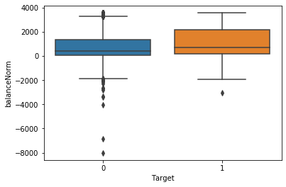

```python
sns.boxplot(csv['Target'],csv['balanceNorm']);
```

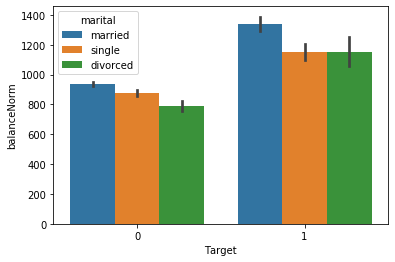

```python
sns.barplot(csv['Target'], csv['balanceNorm'],hue=csv['marital']);
```

##### - We see that client that have higher account balance and are a married couple have higher rate of hitting the target ( subscribe term deposit).

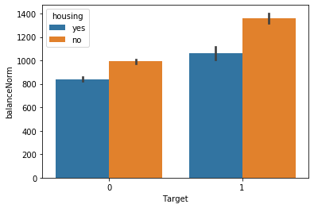

```python
sns.barplot(csv['Target'], csv['balanceNorm'],hue=csv['housing']);
```

##### - We see that client with higher account balance and with no housing loan have slightly higher rate of hitting the target ( subscribe term deposit).

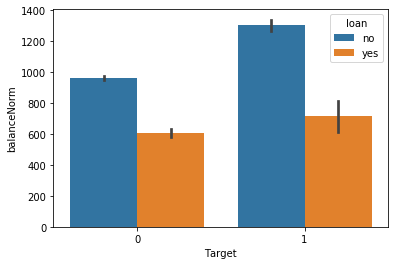

```python
sns.barplot(csv['Target'], csv['balanceNorm'],hue=csv['loan']);
```

##### - We see that client with higher account balance and with no personal loan have higher chance of subscribing to term deposit.

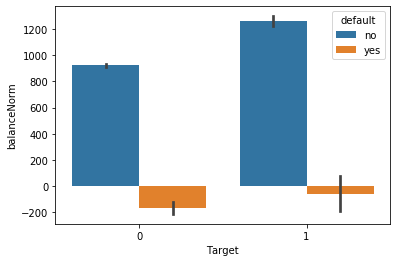

```python
sns.barplot(csv['Target'], csv['balanceNorm'],hue=csv['default']);
```

##### - We see that client who have negative account balance and who have defaulted most probably do not end up subscribing to term deposit.

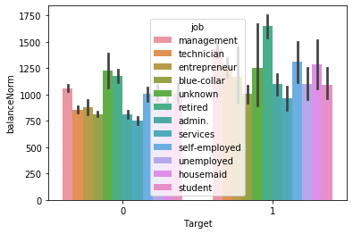

```python
sns.barplot(csv['Target'], csv['balanceNorm'],hue=csv['job']);
```

##### - From the graph above , we see that type of job doesnt make a significant impact on hitting the target.

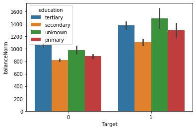

```python
sns.barplot(csv['Target'], csv['balanceNorm'],hue=csv['education']);
```

##### - Removing unknown/missing information, We see that education leval ratio remains the same and doesnt impact on client subscribing to deposit term.

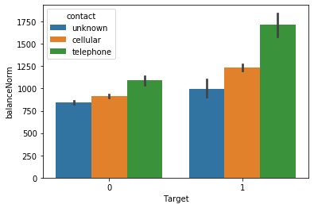

```python
sns.barplot(csv['Target'], csv['balanceNorm'],hue=csv['contact']);
```

##### - We see that communication through telephone does a better job of hitting the target. ( unknown/missing information category if filled approroately can change this prediction).

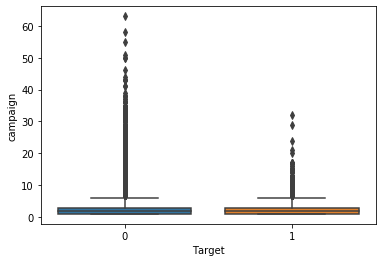

```python
sns.boxplot(csv['Target'],csv['campaign']);
```

##### - We see from above trend that after a certain number of contacts made ( under 10) , the success rate of convincing the client doesnt get impacted by increasing the number of calls / contact.

#### b. Please provide comments in jupyter notebook regarding the steps you take and insights drawn from the plots

#### Summary of relationship between attributes and target:

##### The attributes impacting strongly to the target are:

##### - balance

##### - housing

##### - loan

##### - default

##### - marital

##### - previous

##### The attributes impacting moderately to the target are:

##### - campaign

##### - contact

##### The attributes weakly impacting the target are:

##### - age

##### - job

##### - education

### 3. Prepare the data for analytics

#### Handle negative value

##### - For attribute Balance , we need not handle the negative values as they make sense to be negative in the analysis.

##### - As for attribute pdays , log transformation of pdays as column 'pdayslog' takes care of the negative value as well as normalizes the range.

#### Transform the data i.e. scale / normalize if required

##### - Attributes like balance , previous are normalized to make sure the skewness is not heavily right and log transformation of pdays is done to handle a large range of value.

```python
# keeping normalized/transformation log of attributes like  pdays,balance,previous
data = csv.drop(['pdays','balance','previous'],axis=1)
# drop poutcome since from univariate analysis we see that the attribute has too much (81%) data pollution with unknown category.
data = data.drop(['poutcome'],axis=1)
data.head(10)
```

|  | age | job | marital | education | default | housing | loan | contact | day | month | duration | campaign | Target | balanceNorm | previousNorm | pdayslog |
| --- | --- | --- | --- | --- | --- | --- | --- | --- | --- | --- | --- | --- | --- | --- | --- | --- |
| 0 | 58 | management | married | tertiary | no | yes | no | unknown | 5 | may | 261 | 1 | 0 | 2143.0 | 0.0 | 0.0 |
| 1 | 44 | technician | single | secondary | no | yes | no | unknown | 5 | may | 151 | 1 | 0 | 29.0 | 0.0 | 0.0 |
| 2 | 33 | entrepreneur | married | secondary | no | yes | yes | unknown | 5 | may | 76 | 1 | 0 | 2.0 | 0.0 | 0.0 |
| 3 | 47 | blue-collar | married | unknown | no | yes | no | unknown | 5 | may | 92 | 1 | 0 | 1506.0 | 0.0 | 0.0 |
| 4 | 33 | unknown | single | unknown | no | no | no | unknown | 5 | may | 198 | 1 | 0 | 1.0 | 0.0 | 0.0 |
| 5 | 35 | management | married | tertiary | no | yes | no | unknown | 5 | may | 139 | 1 | 0 | 231.0 | 0.0 | 0.0 |
| 6 | 28 | management | single | tertiary | no | yes | yes | unknown | 5 | may | 217 | 1 | 0 | 447.0 | 0.0 | 0.0 |
| 7 | 42 | entrepreneur | divorced | tertiary | yes | yes | no | unknown | 5 | may | 380 | 1 | 0 | 2.0 | 0.0 | 0.0 |
| 8 | 58 | retired | married | primary | no | yes | no | unknown | 5 | may | 50 | 1 | 0 | 121.0 | 0.0 | 0.0 |
| 9 | 43 | technician | single | secondary | no | yes | no | unknown | 5 | may | 55 | 1 | 0 | 593.0 | 0.0 | 0.0 |

#### Convert categories which are independent of each other and maintain order

```python
for feature in data.columns: # Loop through all columns in the dataframe
    if data[feature].dtype == 'object': # Only apply for columns with categorical strings
        data[feature] = pd.Categorical(data[feature])# Replace strings with an integer
data.dtypes
```

```
age                int64
job             category
marital         category
education       category
default         category
housing         category
loan            category
contact         category
day                int64
month           category
duration           int64
campaign           int64
Target             int64
balanceNorm      float64
previousNorm     float64
pdayslog         float64
dtype: object
```

```python
print(data.job.value_counts())
print(data.marital.value_counts())
print(data.education.value_counts())
print(data.default.value_counts())
print(data.housing.value_counts())
print(data.loan.value_counts())
print(data.contact.value_counts())
print(data.month.value_counts())
```

```
blue-collar      9732
management       9458
technician       7597
admin.           5171
services         4154
retired          2264
self-employed    1579
entrepreneur     1487
unemployed       1303
housemaid        1240
student           938
unknown           288
Name: job, dtype: int64
married     27214
single      12790
divorced     5207
Name: marital, dtype: int64
secondary    23202
tertiary     13301
primary       6851
unknown       1857
Name: education, dtype: int64
no     44396
yes      815
Name: default, dtype: int64
yes    25130
no     20081
Name: housing, dtype: int64
no     37967
yes     7244
Name: loan, dtype: int64
cellular     29285
unknown      13020
telephone     2906
Name: contact, dtype: int64
may    13766
jul     6895
aug     6247
jun     5341
nov     3970
apr     2932
feb     2649
jan     1403
oct      738
sep      579
mar      477
dec      214
Name: month, dtype: int64
```

```python
# replace categories with ordered values wherever required
replaceStruct = {
                "education":     {"primary": 1, "secondary": 2 ,"tertiary": 3 ,"unknown":-1},
                "contact": {"cellular": 1, "telephone":2 ,"unknown":-1},
                  "default":     {"no": 0, "yes": 1 } ,
                  "month":     {"jan":0,"feb":1,"mar":2,"apr":3,"may": 4, "jun": 5,"jul": 6,"aug": 7,"sep": 8,"oct": 9,
                   "nov": 10,"dec": 11,}

                    }
#One hot coding for columns where order isnt recognized and doesnt matter
oneHotCols=["job","marital","housing","loan","month"]
```

```python
data=data.replace(replaceStruct)
data=pd.get_dummies(data, columns=oneHotCols)
data.head(10)
```

|  | age | education | default | contact | day | duration | campaign | Target | balanceNorm | previousNorm | ... | month_2 | month_3 | month_4 | month_5 | month_6 | month_7 | month_8 | month_9 | month_10 | month_11 |
| --- | --- | --- | --- | --- | --- | --- | --- | --- | --- | --- | --- | --- | --- | --- | --- | --- | --- | --- | --- | --- | --- |
| 0 | 58 | 3 | 0 | -1 | 5 | 261 | 1 | 0 | 2143.0 | 0.0 | ... | 0 | 0 | 1 | 0 | 0 | 0 | 0 | 0 | 0 | 0 |
| 1 | 44 | 2 | 0 | -1 | 5 | 151 | 1 | 0 | 29.0 | 0.0 | ... | 0 | 0 | 1 | 0 | 0 | 0 | 0 | 0 | 0 | 0 |
| 2 | 33 | 2 | 0 | -1 | 5 | 76 | 1 | 0 | 2.0 | 0.0 | ... | 0 | 0 | 1 | 0 | 0 | 0 | 0 | 0 | 0 | 0 |
| 3 | 47 | -1 | 0 | -1 | 5 | 92 | 1 | 0 | 1506.0 | 0.0 | ... | 0 | 0 | 1 | 0 | 0 | 0 | 0 | 0 | 0 | 0 |
| 4 | 33 | -1 | 0 | -1 | 5 | 198 | 1 | 0 | 1.0 | 0.0 | ... | 0 | 0 | 1 | 0 | 0 | 0 | 0 | 0 | 0 | 0 |
| 5 | 35 | 3 | 0 | -1 | 5 | 139 | 1 | 0 | 231.0 | 0.0 | ... | 0 | 0 | 1 | 0 | 0 | 0 | 0 | 0 | 0 | 0 |
| 6 | 28 | 3 | 0 | -1 | 5 | 217 | 1 | 0 | 447.0 | 0.0 | ... | 0 | 0 | 1 | 0 | 0 | 0 | 0 | 0 | 0 | 0 |
| 7 | 42 | 3 | 1 | -1 | 5 | 380 | 1 | 0 | 2.0 | 0.0 | ... | 0 | 0 | 1 | 0 | 0 | 0 | 0 | 0 | 0 | 0 |
| 8 | 58 | 1 | 0 | -1 | 5 | 50 | 1 | 0 | 121.0 | 0.0 | ... | 0 | 0 | 1 | 0 | 0 | 0 | 0 | 0 | 0 | 0 |
| 9 | 43 | 2 | 0 | -1 | 5 | 55 | 1 | 0 | 593.0 | 0.0 | ... | 0 | 0 | 1 | 0 | 0 | 0 | 0 | 0 | 0 | 0 |

10 rows × 42 columns

#### Create the training set and test set in ratio of 70:30

```python
from sklearn.preprocessing import LabelEncoder   # import label encoder
from sklearn.model_selection import train_test_split
from sklearn.tree import DecisionTreeClassifier
from sklearn import tree
from sklearn import metrics
from sklearn.linear_model import LogisticRegression
from sklearn.datasets import make_classification
from sklearn.metrics import accuracy_score, confusion_matrix, recall_score, roc_auc_score, precision_score,roc_curve, auc,f1_score
from matplotlib import pyplot
import pickle
```

```python
labelencoder = LabelEncoder()
csv["Target"] = labelencoder.fit_transform(csv.Target) # returns label encoded variable(s)

X = data.drop("Target" , axis=1)
y = data.pop("Target")
```

```python
X_train, X_test, y_train, y_test = train_test_split(X, y, test_size=.30, random_state=1)
```

### 4. Create the ensemble model

#### Building Logistic Regression Model

```python
# Fit the model on train
model = LogisticRegression(solver="liblinear")
model.fit(X_train, y_train)

y_predict = model.predict(X_test)

coef_df = pd.DataFrame(model.coef_)
coef_df['intercept'] = model.intercept_

# Model Score
model_score = model.score(X_test, y_test)
model_score1 = model.score(X_train, y_train)
print('Score on Training data',model_score1)
print('Score on Training data',model_score)
```

```
Score on Training data 0.8957247132429614
Score on Training data 0.8931731052786789
```

#### Building Decision Tree Model

```python
dTree = DecisionTreeClassifier(criterion = 'gini', random_state=1)
dTree.fit(X_train, y_train)
print("Score on Training data ",dTree.score(X_train, y_train))
print("Score on Test Data" ,dTree.score(X_test, y_test))
```

```
Score on Training data  1.0
Score on Test Data 0.8728251253317605
```

##### The score on training data is way higher than on test data which suggests overfitting.

##### Reducing over fitting (Regularization) with pruning the tree till depth as 5

```python
dTreeReg = DecisionTreeClassifier(criterion = 'gini', max_depth = 5, random_state=1)
dTreeReg.fit(X_train, y_train)
print("Score on Training data ",dTreeReg.score(X_train, y_train))
print("Score on Test Data" ,dTreeReg.score(X_test, y_test))
y_predict_tree = dTreeReg.predict(X_test)
```

```
Score on Training data  0.8967674661105318
Score on Test Data 0.893320554408729
```

##### we can see that the score on training data and test data or pretty much equal

#### Using confusion matrix to evaluate class level metrics i.e. Precision/Recall.

```
 Evaluation for Logistic Regression
  Precision =  0.5702479338842975
  Recall = 0.26692456479690524
 Evaluation for Decison Tree
  Precision =  0.5809968847352025
  Recall = 0.24049000644745325
```

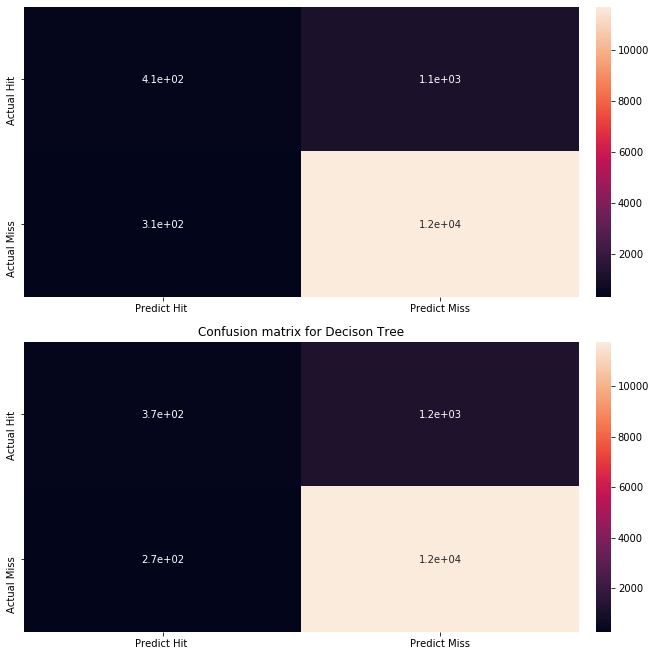

```python
fig, axarr = plt.subplots(nrows=2, ncols=1,
                        figsize=(9, 9), constrained_layout=True)

lst = {'Logistic Regression': y_predict, 'Decison Tree': y_predict_tree}
idx = 0
for key, value in lst.items():
    row = idx%2;
    idx = idx + 1;
    cm=metrics.confusion_matrix(y_test, value, labels=[1, 0])
    df_cm = pd.DataFrame(cm, index = [i for i in ["Actual Hit","Actual Miss"]],
                  columns = [i for i in ["Predict Hit ","Predict Miss"]])
    #plt.figure(figsize = (7,5))
    plt.title('Confusion matrix for ' + key )
    map = sns.heatmap(df_cm, annot=True,ax=axarr[row])
    print ('\033[1m Evaluation for ' + key + '\033[0m')
    print('  Precision = ', cm[0][0]/(cm[0][0]+ cm[1][0]))
    print('  Recall =', cm[0][0]/(cm[0][0]+ cm[0][1]))
```

#### Accuracy and F1 score of the models

```python
#Calculate Accuracy , Precisison , Recall and F1  Score

print('\033[1mLogistic Regression Model \033[0m')
#Accuracy
test_accuracy = accuracy_score(y_test, y_predict,1)
print('Accuracy is : {} %'.format(test_accuracy*100))


#F1 score
F1=f1_score(y_test, y_predict, zero_division=1)
print('F1 Score is : {}'.format(F1))

#ROC Curve
# predict probabilities for ROC curve to get the positive outcome only
lr_probs = model.predict_proba(X_test)
lr_probs = lr_probs[:, 1]


#AUC score
lr_auc = roc_auc_score(y_test, lr_probs)
# summarize scores
print('Logistic: ROC AUC=%.3f' % (lr_auc))

print('===========================================================')

print('\033[1mDecisiom Tree Model \033[0m')
#Accuracy
test_accuracy = accuracy_score(y_test, y_predict_tree,1)
print('Accuracy is : {} %'.format(test_accuracy*100))


#F1 score
F1=f1_score(y_test, y_predict_tree, zero_division=1)
print('F1 Score is : {}'.format(F1))
#ROC Curve
# predict probabilities for ROC curve to get the positive outcome only
lr_probs = dTreeReg.predict_proba(X_test)
lr_probs = lr_probs[:, 1]


#AUC score
lr_auc = roc_auc_score(y_test, lr_probs)
# summarize scores
print('Logistic: ROC AUC=%.3f' % (lr_auc))
```

```
Logistic Regression Model
Accuracy is : 89.31731052786789 %
F1 Score is : 0.3636363636363636
Logistic: ROC AUC=0.895
===========================================================
Decisiom Tree Model
Accuracy is : 89.3320554408729 %
F1 Score is : 0.3401732786137711
Logistic: ROC AUC=0.821
```

### 5 Better the ensemble models using (Bagging and Boosting)

#### To evaluate and better performance we can use the following bagging and boosting techniques

#### - Bagging Techinique use on decision tree model (without pruning)

```python
from sklearn.ensemble import BaggingClassifier

bgcl = BaggingClassifier(base_estimator=dTree, n_estimators=50,random_state=1)
bgcl = bgcl.fit(X_train, y_train)
```

```
Bagging Model Score : 0.9046741374225892 %
Accuracy is : 90.46741374225891 %
F1 Score is : 0.540348382509776
```

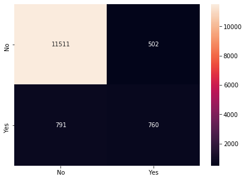

```python
y_predict_bgcl = bgcl.predict(X_test)

print('Bagging Model Score : {} %' .format(bgcl.score(X_test , y_test)))

#Accuracy
test_accuracy = accuracy_score(y_test, y_predict_bgcl,1)
print('Accuracy is : {} %'.format(test_accuracy*100))

#F1 score
F1=f1_score(y_test, y_predict_bgcl, zero_division=1)
print('F1 Score is : {}'.format(F1))

cm=metrics.confusion_matrix(y_test, y_predict_bgcl,labels=[0, 1])

df_cm = pd.DataFrame(cm, index = [i for i in ["No","Yes"]],
                  columns = [i for i in ["No","Yes"]])
plt.figure(figsize = (7,5))
sns.heatmap(df_cm, annot=True ,fmt='g')
```

#### - Using Bagging classifier with less number of decision trees n_estimators=10

```
Bagging Model Score for 10 n_estimator: 0.9002506635210852 %
Accuracy is : 90.02506635210852 %
F1 Score is : 0.48808172531214533
```

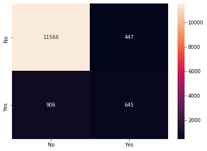

```python
# Using Bagging classifier with less number of decision trees

bgcl_10 = BaggingClassifier(n_estimators=10,random_state=1)
bgcl_10 = bgcl_10.fit(X_train, y_train)

y_predict_bgcl10 = bgcl_10.predict(X_test)

print('Bagging Model Score for 10 n_estimator: {} %' .format(bgcl_10.score(X_test , y_test)))

#Accuracy
test_accuracy = accuracy_score(y_test, y_predict_bgcl10,1)
print('Accuracy is : {} %'.format(test_accuracy*100))

#F1 score
F1=f1_score(y_test, y_predict_bgcl10, zero_division=1)
print('F1 Score is : {}'.format(F1))

cm=metrics.confusion_matrix(y_test, y_predict_bgcl10,labels=[0, 1])

df_cm = pd.DataFrame(cm, index = [i for i in ["No","Yes"]],
                  columns = [i for i in ["No","Yes"]])
plt.figure(figsize = (7,5))
sns.heatmap(df_cm, annot=True ,fmt='g')
```

#### - Using Bagging classifier on pruned tree

```
Bagging Model Score with pruned tree: 0.8977440283102329 %
Accuracy is : 89.7744028310233 %
F1 Score is : 0.4228048272992093
```

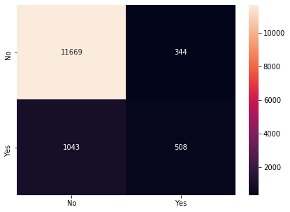

```python
# Using Bagging classifier on pruned tree

bgcl_reg = BaggingClassifier(base_estimator=dTreeReg, n_estimators=50,random_state=1)
bgcl_reg = bgcl_reg.fit(X_train, y_train)



y_predict_bgcl_reg = bgcl_reg.predict(X_test)

print('Bagging Model Score with pruned tree: {} %' .format(bgcl_reg.score(X_test , y_test)))

#Accuracy
test_accuracy = accuracy_score(y_test, y_predict_bgcl_reg,1)
print('Accuracy is : {} %'.format(test_accuracy*100))

#F1 score
F1=f1_score(y_test, y_predict_bgcl_reg, zero_division=1)
print('F1 Score is : {}'.format(F1))

cm=metrics.confusion_matrix(y_test, y_predict_bgcl_reg,labels=[0, 1])

df_cm = pd.DataFrame(cm, index = [i for i in ["No","Yes"]],
                  columns = [i for i in ["No","Yes"]])
plt.figure(figsize = (7,5))
sns.heatmap(df_cm, annot=True ,fmt='g')
```

#### Observation: Bagging works better with overfitted decision trees and more number of n_estimators(trees)

#### - Using RandomForest Classifier on decision tree model (without pruning)

```
Random Forest Model Score for 50 n_estimator: 0.9026835741669124 %
Accuracy is : 90.26835741669123 %
F1 Score is : 0.5107487027427725
```

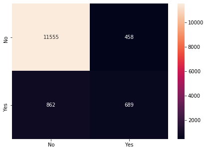

```python
from sklearn.ensemble import RandomForestClassifier
rfcl = RandomForestClassifier(n_estimators = 50, random_state=1,max_features=12)
rfcl = rfcl.fit(X_train, y_train)

y_predict_rfcl = rfcl.predict(X_test)

print('Random Forest Model Score for 50 n_estimator: {} %' .format(rfcl.score(X_test , y_test)))

#Accuracy
test_accuracy = accuracy_score(y_test, y_predict_rfcl,1)
print('Accuracy is : {} %'.format(test_accuracy*100))

#F1 score
F1=f1_score(y_test, y_predict_rfcl, zero_division=1)
print('F1 Score is : {}'.format(F1))

cm=metrics.confusion_matrix(y_test, y_predict_rfcl,labels=[0, 1])

df_cm = pd.DataFrame(cm, index = [i for i in ["No","Yes"]],
                  columns = [i for i in ["No","Yes"]])
plt.figure(figsize = (7,5))
sns.heatmap(df_cm, annot=True ,fmt='g')
```

#### - Using RandomForest Classifier with different n_estimator ( number of trees) and max_features

```python
from sklearn.datasets import make_blobs
from sklearn.model_selection import RepeatedStratifiedKFold
from sklearn.model_selection import GridSearchCV
from sklearn.ensemble import RandomForestClassifier

# define models and parameters
model = RandomForestClassifier()
n_estimators = [10, 50, 100]
max_features = ['sqrt', 'log2']

# define grid search
grid = dict(n_estimators=n_estimators,max_features=max_features)
cv = RepeatedStratifiedKFold(n_splits=10, n_repeats=3, random_state=1)
grid_search = GridSearchCV(estimator=model, param_grid=grid, n_jobs=-1, cv=cv, scoring='accuracy',error_score=0)
grid_result = grid_search.fit(X_train, y_train)

# summarize results
print("Best: %f using %s" % (grid_result.best_score_, grid_result.best_params_))
means = grid_result.cv_results_['mean_test_score']
stds = grid_result.cv_results_['std_test_score']
params = grid_result.cv_results_['params']
for mean, stdev, param in zip(means, stds, params):
    print("%f (%f) with: %r" % (mean, stdev, param))
```

```
Best: 0.902919 using {'max_features': 'sqrt', 'n_estimators': 100}
0.895377 (0.004200) with: {'max_features': 'sqrt', 'n_estimators': 10}
0.901349 (0.004171) with: {'max_features': 'sqrt', 'n_estimators': 50}
0.902919 (0.004722) with: {'max_features': 'sqrt', 'n_estimators': 100}
0.894798 (0.003936) with: {'max_features': 'log2', 'n_estimators': 10}
0.899874 (0.004158) with: {'max_features': 'log2', 'n_estimators': 50}
0.902392 (0.004520) with: {'max_features': 'log2', 'n_estimators': 100}
```

```python
rfcl_best = RandomForestClassifier(n_estimators = 100, random_state=1,max_features='sqrt')
rfcl_best = rfcl_best.fit(X_train, y_train)

y_predict_rfcl_best = rfcl_best.predict(X_test)
```

#### Observation : From the above we see that we get the best Model score when n_estimator is high (100) and less number of max features sampled ( sqrt)

```
Random Forest Model Score for 50 n_estimator: 0.8858006487761723 %
Accuracy is : 88.58006487761723 %
F1 Score is : 0.005138086062941555
```

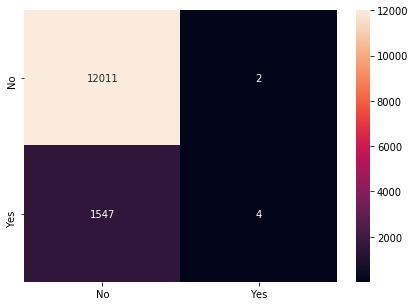

```python
from sklearn.ensemble import RandomForestClassifier
rfcl = RandomForestClassifier(max_depth=3,n_estimators = 50, random_state=1,max_features=12)
rfcl = rfcl.fit(X_train, y_train)

y_predict_rfcl = rfcl.predict(X_test)

print('Random Forest Model Score for 50 n_estimator: {} %' .format(rfcl.score(X_test , y_test)))

#Accuracy
test_accuracy = accuracy_score(y_test, y_predict_rfcl,1)
print('Accuracy is : {} %'.format(test_accuracy*100))

#F1 score
F1=f1_score(y_test, y_predict_rfcl, zero_division=1)
print('F1 Score is : {}'.format(F1))

cm=metrics.confusion_matrix(y_test, y_predict_rfcl,labels=[0, 1])

df_cm = pd.DataFrame(cm, index = [i for i in ["No","Yes"]],
                  columns = [i for i in ["No","Yes"]])
plt.figure(figsize = (7,5))
sns.heatmap(df_cm, annot=True ,fmt='g')
```

#### Using AdaBoosting

```
Adaboosting Model Score : 0.8950162194043055 %
Accuracy is : 89.50162194043055 %
F1 Score is : 0.42394822006472493
```

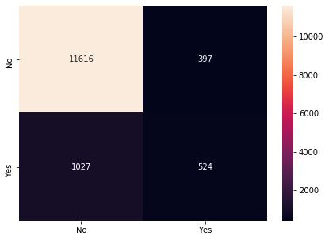

```python
from sklearn.ensemble import AdaBoostClassifier
abcl = AdaBoostClassifier(n_estimators=50, random_state=1)
#abcl = AdaBoostClassifier( n_estimators=50,random_state=1)
abcl = abcl.fit(X_train, y_train)

y_predict_abcl = abcl.predict(X_test)

print('Adaboosting Model Score : {} %' .format(abcl.score(X_test , y_test)))

#Accuracy
test_accuracy = accuracy_score(y_test, y_predict_abcl,1)
print('Accuracy is : {} %'.format(test_accuracy*100))

#F1 score
F1=f1_score(y_test, y_predict_abcl, zero_division=1)
print('F1 Score is : {}'.format(F1))

cm=metrics.confusion_matrix(y_test, y_predict_abcl,labels=[0, 1])

df_cm = pd.DataFrame(cm, index = [i for i in ["No","Yes"]],
                  columns = [i for i in ["No","Yes"]])
plt.figure(figsize = (7,5))
sns.heatmap(df_cm, annot=True ,fmt='g')
```

#### Using Adaboosting with more stronger tree more depth

```
Adaboosting Model Score : 0.8731937481568859 %
Accuracy is : 89.50162194043055 %
F1 Score is : 0.4694632942628007
```

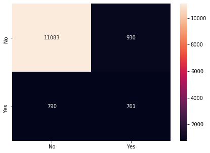

```python
from sklearn.ensemble import AdaBoostClassifier
abcl_dp3 = AdaBoostClassifier(base_estimator=dTree,n_estimators=50, random_state=1)
abcl_dp3 = abcl_dp3.fit(X_train, y_train)

y_predict_abcl_dp3 = abcl_dp3.predict(X_test)

print('Adaboosting Model Score : {} %' .format(abcl_dp3.score(X_test , y_test)))

#Accuracy
test_accuracy = accuracy_score(y_test, y_predict_abcl,1)
print('Accuracy is : {} %'.format(test_accuracy*100))

#F1 score
F1=f1_score(y_test, y_predict_abcl_dp3, zero_division=1)
print('F1 Score is : {}'.format(F1))

cm=metrics.confusion_matrix(y_test, y_predict_abcl_dp3,labels=[0, 1])

df_cm = pd.DataFrame(cm, index = [i for i in ["No","Yes"]],
                  columns = [i for i in ["No","Yes"]])
plt.figure(figsize = (7,5))
sns.heatmap(df_cm, annot=True ,fmt='g')
```

#### Observation : The boosting model generally perfoms better with weaker trees interms of model scores.

#### Using GradientBoost

```
Gradient boosting Model Score : 0.8980389265703332 %
Accuracy is : 89.50162194043055 %
F1 Score is : 0.41472704189589504
```

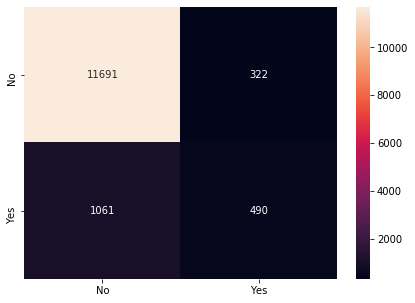

```python
# doesnt allow choosing model for us
from sklearn.ensemble import GradientBoostingClassifier
gbcl = GradientBoostingClassifier(n_estimators = 50,random_state=1)
gbcl = gbcl.fit(X_train, y_train)

y_predict_gbcl = gbcl.predict(X_test)

print('Gradient boosting Model Score : {} %' .format(gbcl.score(X_test , y_test)))

#Accuracy
test_accuracy = accuracy_score(y_test, y_predict_abcl,1)
print('Accuracy is : {} %'.format(test_accuracy*100))

#F1 score
F1=f1_score(y_test, y_predict_gbcl, zero_division=1)
print('F1 Score is : {}'.format(F1))

cm=metrics.confusion_matrix(y_test, y_predict_gbcl,labels=[0, 1])

df_cm = pd.DataFrame(cm, index = [i for i in ["No","Yes"]],
                  columns = [i for i in ["No","Yes"]])
plt.figure(figsize = (7,5))
sns.heatmap(df_cm, annot=True ,fmt='g')
```

### 5 Make a DataFrame to compare models and their metrics. Give conclusion regardingthe best algorithm and your reason behind it.

```python
from IPython.display import display, HTML

lst = [y_predict_bgcl,
       y_predict_bgcl10,
       y_predict_bgcl_reg,
       y_predict_rfcl,
       y_predict_rfcl_best,
       y_predict_abcl,
       y_predict_abcl_dp3,
       y_predict_gbcl]

lst1 = [bgcl, bgcl_10, bgcl_reg,rfcl, rfcl_best,abcl,abcl_dp3, gbcl]


listing = [];

for idx in range(len(lst)):
    #Accuracy
    test_accuracy = accuracy_score(y_test, lst[idx],1)*100
    #F1 score
    F1=f1_score(y_test, lst[idx], zero_division=1)
    #print(lst1[idx].score(X_test , lst[idx]))
    listing.append([lst1[idx].score(X_test , y_test),lst1[idx].score(X_train , y_train),test_accuracy,F1])



df_cm = pd.DataFrame(listing, index = [i for i in ["Bagging","Bagging 10 n_estimator","Bagging with pruned tree"
                                              ,"Random Forest Classification",
                                                   "Random Forest Classification (best features)",
                                                   "Adaboosting",
                                             "Adaboosting with stronger trees","Gradient boosting"]],
                  columns = [i for i in ["Model Score(test)","Model Score(train)","Accuracy (%)","F1 Score"]])



display(HTML(df_cm.to_html()))
df_cm.to_csv("Performance_Matrix.csv")
```

|  | Model Score(test) | Model Score(train) | Accuracy (%) | F1 Score |
| --- | --- | --- | --- | --- |
| Bagging | 0.904674 | 0.999810 | 90.467414 | 0.540348 |
| Bagging 10 n_estimator | 0.900251 | 0.992890 | 90.025066 | 0.488082 |
| Bagging with pruned tree | 0.897744 | 0.901665 | 89.774403 | 0.422805 |
| Random Forest Classification | 0.885801 | 0.882074 | 88.580065 | 0.005138 |
| Random Forest Classification (best features) | 0.903495 | 0.999937 | 90.349454 | 0.481173 |
| Adaboosting | 0.895016 | 0.896167 | 89.501622 | 0.423948 |
| Adaboosting with stronger trees | 0.873194 | 1.000000 | 87.319375 | 0.469463 |
| Gradient boosting | 0.898039 | 0.903372 | 89.803893 | 0.414727 |

#### Observation:

##### 2) Although it is important to make sure the model is not biased against the training model and therefore we should not consider models which have huge difference of model scores between training and testing data.

#### Conclusion:

##### - From the above observations , we consider Bagging with pruned tree , Adaboosting and Gradient boosting as the model with very low bias and better suited for our data.

##### - Therefore for the given data, Gradient Boosting and Adaboosting are equally best suited models. Although former is better interms of Accuracy (89.8 %) and the later is better interms of F1 score (0.42).